# HDAT9600 Linear Models Assignment

Due 6/7/2020

Murray Keogh

06 July, 2020

## Instructions

This file is the R Markdown document in which you need to complete your HDAT9600 Linear Models assignment. This assignment is assessed and will count for 25% of the total course mark.

You should complete the tasks described below, in the spaces provided. Don’t hesitate to ask for help (via OpenLearning @andb) — but remember that these are **individual** assignments and thus what you submit should be your own work, and you need to both understand and be able to explain what you did in your solutions.

Each task below attracts the indicated number of marks (out of a total of 20 marks for the assignment).

## Task 1 (3 marks)

In this question, you will be using the `prostate` dataset which comes with the *faraway* package for R. You should already have the *faraway* package installed. If not, install it now using the Packages tab in RStudio or the `install.packages()` function at R console prompt.

Details of the `prostate` dataset can be viewed on the manual (help) page for the dataset in the *faraway* package. You can display that in the Help pane in RStudio using the help search functions, or by just typing `?faraway::prostate` at the R console.

You will notice that the dataset contains details of 97 men with [prostate cancer](https://en.wikipedia.org/wiki/Prostate_cancer) who were scheduled to receive [radical prostatectomy](https://en.wikipedia.org/wiki/Prostatectomy) surgery. The dataset doesn’t contain details of whether they actually underwent that surgery, nor its outcomes, just various data items about the patients and their prostate cancers **prior** to the scheduled surgery.

```r
# this loads the prostate dataset and makes it available for code in
# subsequent code chunks.
data(prostate, package="faraway")
```

Write R code to carry out the following:

1. Using the `prostate` dataset, fit a linear model with `lpsa` as the outcome variable and the other variables as the predictors.
2. Compute and display the 95% and 90% confidence intervals for the `lweight` and `age` predictor variables. (Hint: examine the manual (help) page for the `confint()` function.)
3. Based on those confidence intervals, state what you can deduce about the *p*-values in the regression summary for the model. Then display the regression summary.
4. Compute and plot a 95% joint confidence region for the `age` and `lbph` predictor variables from this model. Also indicate the origin point in this plot.
5. The location of the origin point with respect to the confidence region indicates the outcome of a particular hypothesis test. State what that hypothesis test is, and what the outcome is.

### Marking rubric, hints and tips

Two marks will be awarded for the R programming tasks, and one mark in total for correct statements about deduction from the confidence intervals (part iii.), and about the hypothesis test and its outcome for the joint confidence regions (part v.). R code must be used for all calculations and to draw the plot.

```r
# fit a linear model with lpsa
plmod <- lm(lpsa ~ lcavol+lweight+age+lbph+svi+lcp+gleason+pgg45,data=prostate)

# produce the 95% and 90% confidence intervals for lweight and age
confint(plmod,'lweight',level = 0.95)
```

```
##             2.5 %    97.5 %
## lweight 0.1166034 0.7923314
```

```r
confint(plmod,'lweight',level = 0.90)
```

```
##               5 %      95 %
## lweight 0.1718466 0.7370883
```

```r
confint(plmod,'age',level = 0.95)
```

```
##           2.5 %      97.5 %
## age -0.04184062 0.002566267
```

```r
confint(plmod,'age',level = 0.90)
```

```
##            5 %         95 %
## age -0.0382102 -0.001064151
```

```r
# display the regression summary for plmod
summary(plmod)
```

```
##
## Call:
## lm(formula = lpsa ~ lcavol + lweight + age + lbph + svi + lcp +
##     gleason + pgg45, data = prostate)
##
## Residuals:
##     Min      1Q  Median      3Q     Max
## -1.7331 -0.3713 -0.0170  0.4141  1.6381
##
## Coefficients:
##              Estimate Std. Error t value Pr(>|t|)
## (Intercept)  0.669337   1.296387   0.516  0.60693
## lcavol       0.587022   0.087920   6.677 2.11e-09 ***
## lweight      0.454467   0.170012   2.673  0.00896 **
## age         -0.019637   0.011173  -1.758  0.08229 .
## lbph         0.107054   0.058449   1.832  0.07040 .
## svi          0.766157   0.244309   3.136  0.00233 **
## lcp         -0.105474   0.091013  -1.159  0.24964
## gleason      0.045142   0.157465   0.287  0.77503
## pgg45        0.004525   0.004421   1.024  0.30886
## ---
## Signif. codes:  0 '***' 0.001 '**' 0.01 '*' 0.05 '.' 0.1 ' ' 1
##
## Residual standard error: 0.7084 on 88 degrees of freedom
## Multiple R-squared:  0.6548, Adjusted R-squared:  0.6234
## F-statistic: 20.86 on 8 and 88 DF,  p-value: < 2.2e-16
```

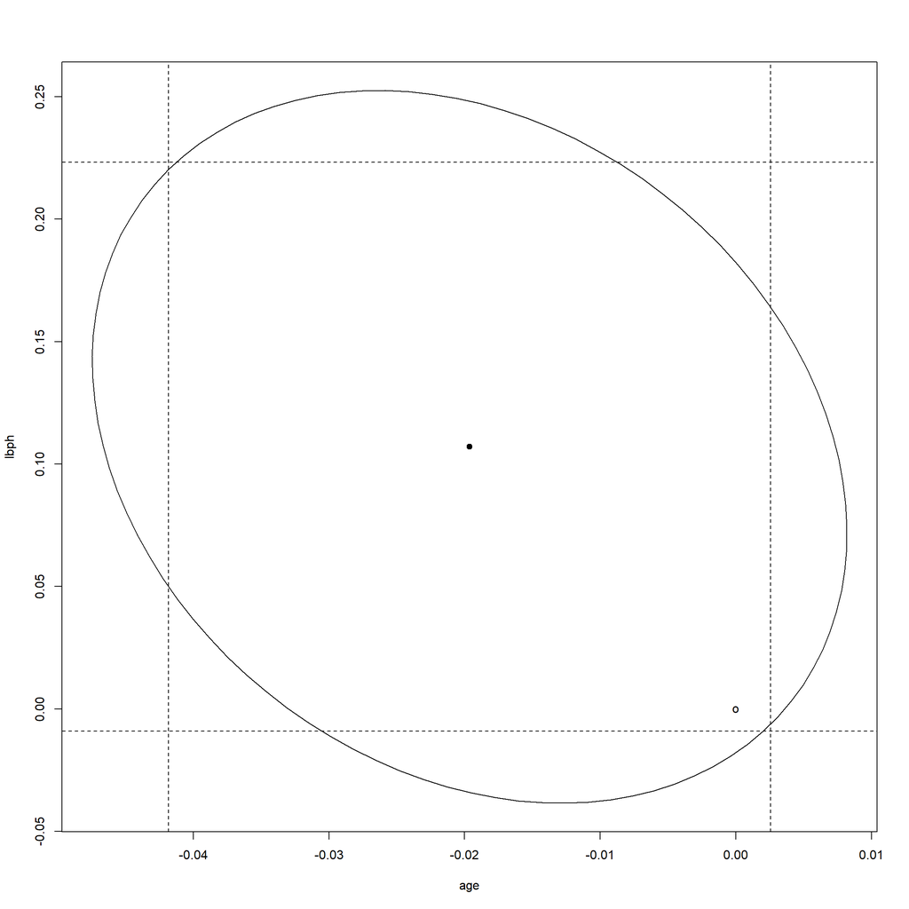

```r
#compute and plot 95% confidence region for age and lbph

# Age and lbph are the 4th and 5th parameters in the model
plot(ellipse::ellipse(plmod, c(4, 5)), type='l')

# add a dot at the point of the best estimates for the two predictors
points(coef(plmod)[4], coef(plmod)[5], pch=19)

# add dotted lines for the univariate confidence limits in two dimensions
abline(v = confint(plmod)[4,], lty=2)
abline(h = confint(plmod)[5,], lty=2)

# add the origin point at 0,0
text(0,0, "o")
```

I can deduce a few things from the 90% and 95% confidence intervals for `lweight` and `age`. I know that the p-value for `lweight` will be less than 0.05 because both the 90% and 95% confidence intervals for `lweight` do not contain zero in the range. I know that the p-value for `age` will fall between 0.05 and 0.10 because the 95% CI for `age` contains zero but the 90% CI does not contain zero.

The origin point is placed at 0,0 to test the joint null hypothesis that $H_0 \ : \ \beta_{\textrm{age}} = \beta_{\textrm{lbph}} = 0$. The joint null hypothesis $H_0 \ : \ \beta_{\textrm{age}} = \beta_{\textrm{lbph}} = 0$ cannot be rejected because the origin (0, 0) lies inside the ellipse.

## Task 2 (7 marks)

In Task 2 of this assignment, you will be using the `fat` dataset which comes with the *faraway* package for R which you should already have installed. If not, install it now using the Packages tab in RStudio or the `install.packages()` function at R console prompt.

```r
# this loads the prostate dataset and makes it available for code in
# subsequent code chunks.
data(fat, package="faraway")
```

1. Fit a linear regression model to the `fat` dataset using `brozek` as the outcome (response) variable and the following variables as predictors: `age`, `weight`, `height`, `neck`, `chest`, `abdom`, `hip`, `thigh`, `knee`, `ankle`, `biceps`, `forearm`, `wrist`. Assign the name `fullfat` to the resulting model object. Print the summary output for this model. (0.5 mark)

```r
# fit a linear model fullfat and print the summary

fullfat <- lm(brozek ~ age+weight+height+neck+chest+abdom+hip+thigh+knee+ankle+biceps+forearm+wrist,data=fat)
summary(fullfat)
```

```
##
## Call:
## lm(formula = brozek ~ age + weight + height + neck + chest +
##     abdom + hip + thigh + knee + ankle + biceps + forearm + wrist,
##     data = fat)
##
## Residuals:
##     Min      1Q  Median      3Q     Max
## -10.264  -2.572  -0.097   2.898   9.327
##
## Coefficients:
##              Estimate Std. Error t value Pr(>|t|)
## (Intercept) -15.29255   16.06992  -0.952  0.34225
## age           0.05679    0.02996   1.895  0.05929 .
## weight       -0.08031    0.04958  -1.620  0.10660
## height       -0.06460    0.08893  -0.726  0.46830
## neck         -0.43754    0.21533  -2.032  0.04327 *
## chest        -0.02360    0.09184  -0.257  0.79740
## abdom         0.88543    0.08008  11.057  < 2e-16 ***
## hip          -0.19842    0.13516  -1.468  0.14341
## thigh         0.23190    0.13372   1.734  0.08418 .
## knee         -0.01168    0.22414  -0.052  0.95850
## ankle         0.16354    0.20514   0.797  0.42614
## biceps        0.15280    0.15851   0.964  0.33605
## forearm       0.43049    0.18445   2.334  0.02044 *
## wrist        -1.47654    0.49552  -2.980  0.00318 **
## ---
## Signif. codes:  0 '***' 0.001 '**' 0.01 '*' 0.05 '.' 0.1 ' ' 1
##
## Residual standard error: 3.988 on 238 degrees of freedom
## Multiple R-squared:  0.749,  Adjusted R-squared:  0.7353
## F-statistic: 54.63 on 13 and 238 DF,  p-value: < 2.2e-16
```

2. Fit a linear regression model to the `fat` dataset using `brozek` as the outcome (response) variable and only the following variables as predictors: `age`, `weight`, `height`, `abdom` (on the basis that they are easily measured by individuals at home with just a tape measure). Assign the name `reducedfat` to the resulting model object. Print the summary output for this model. (0.5 mark)

```r
# fit a linear model reducedfat and print the summary

reducedfat <- lm(brozek ~ age+weight+height+abdom,data=fat)
summary(reducedfat)
```

```
##
## Call:
## lm(formula = brozek ~ age + weight + height + abdom, data = fat)
##
## Residuals:
##      Min       1Q   Median       3Q      Max
## -11.5105  -2.9346   0.0087   2.8942   9.4179
##
## Coefficients:
##               Estimate Std. Error t value Pr(>|t|)
## (Intercept) -32.769636   6.541902  -5.009 1.04e-06 ***
## age          -0.007051   0.024342  -0.290    0.772
## weight       -0.123722   0.025046  -4.940 1.44e-06 ***
## height       -0.116694   0.082727  -1.411    0.160
## abdom         0.889704   0.067267  13.226  < 2e-16 ***
## ---
## Signif. codes:  0 '***' 0.001 '**' 0.01 '*' 0.05 '.' 0.1 ' ' 1
##
## Residual standard error: 4.126 on 247 degrees of freedom
## Multiple R-squared:  0.7211, Adjusted R-squared:  0.7166
## F-statistic: 159.7 on 4 and 247 DF,  p-value: < 2.2e-16
```

3. Compare the `reducedfat` model to the `fullfat` model using the `anova()` function. Hint: look at the section on “Testing pairs of predictors” in Chapter 2. The same method can be used to compare models that differ by more than just two predictors. (1 mark)

```r
fav <- anova(reducedfat,fullfat)
print(fav)
```

```
## Analysis of Variance Table
##
## Model 1: brozek ~ age + weight + height + abdom
## Model 2: brozek ~ age + weight + height + neck + chest + abdom + hip +
##     thigh + knee + ankle + biceps + forearm + wrist
##   Res.Df    RSS Df Sum of Sq      F   Pr(>F)
## 1    247 4205.0
## 2    238 3785.1  9     419.9 2.9336 0.002558 **
## ---
## Signif. codes:  0 '***' 0.001 '**' 0.01 '*' 0.05 '.' 0.1 ' ' 1
```

4. Comment on whether it is justifiable to use the simplified model or not. (0.5 mark)

We can reject the null hypothesis because the *p*-value is small. Thus, it is not reasonable to simplify the model by removing the predictors : `neck`,`chest`,`hip`,`thigh`,`knee`,`ankle`,`biceps`,`forearm`, and `wrist`. From the `fullfat` regression output, I know that the variables `wrist`,`forearm`, and `neck` had small *p*-values and thus contribute to the model and have an impact when removed.

5. Compute a 95% **prediction** interval for the **mean** (not median) predictor values for the full and reduced models, and write a single sentence comparing the intervals. Do the intervals vary by much? (1 mark)

```r
# get all the predictors as a matrix for each model
fullfatmod_matrix <- model.matrix(fullfat)
reducedfatmod_matrix <- model.matrix(reducedfat)

# calculate means for each of the predictor variables for each model
(mean_fullfat <- apply(fullfatmod_matrix, 2, mean))
```

```
## (Intercept)         age      weight      height        neck       chest
##     1.00000    44.88492   178.92440    70.14881    37.99206   100.82421
##       abdom         hip       thigh        knee       ankle      biceps
##    92.55595    99.90476    59.40595    38.59048    23.10238    32.27341
##     forearm       wrist
##    28.66389    18.22976
```

```r
(mean_reducedfat <- apply(reducedfatmod_matrix, 2, mean))
```

```
## (Intercept)         age      weight      height       abdom
##     1.00000    44.88492   178.92440    70.14881    92.55595
```

```r
#use predict to calculate the prediction interval mean body fat percentage for each model
predict(fullfat, new=as.data.frame(t(mean_fullfat)), interval="prediction")
```

```
##        fit      lwr     upr
## 1 18.93849 11.06669 26.8103
```

```r
predict(reducedfat, new=as.data.frame(t(mean_reducedfat)), interval="prediction")
```

```
##        fit      lwr      upr
## 1 18.93849 10.79562 27.08137
```

The predicted mean body fat percentage is exactly the same for each model, but the prediction interval for the fullfat model is narrower than the reducedfat model by approximately 0.5.

6. Repeat step e. but this time for the **confidence** intervals for the for the **mean** (not median) predictor values for the full and reduced models, and again write a single sentence comparing the intervals. Do the intervals vary by much? (1 mark)

```r
# get all the predictors as a matrix for each model
fullfatmod_matrix <- model.matrix(fullfat)
reducedfatmod_matrix <- model.matrix(reducedfat)

# calculate means for each of the predictor variables for each model
mean_fullfat <- apply(fullfatmod_matrix, 2, mean)
mean_reducedfat <- apply(reducedfatmod_matrix, 2, mean)

#use predict to calculate the confidence interval for mean body fat percentage for each model
predict(fullfat, new=as.data.frame(t(mean_fullfat)), interval="confidence")
```

```
##        fit     lwr      upr
## 1 18.93849 18.4436 19.43339
```

```r
predict(reducedfat, new=as.data.frame(t(mean_reducedfat)), interval="confidence")
```

```
##        fit      lwr      upr
## 1 18.93849 18.42655 19.45043
```

The interval for the fullfat model is narrower than the interval for the reducedfat model by approximately 0.04.

7. Using the reduced model, identify the two observations with the greatest Cook’s distance. Remove (or exclude) those observations form the dataset and re-fit the reduced model. Comment on any differences you see in the model summary (if any). (1.5 marks)

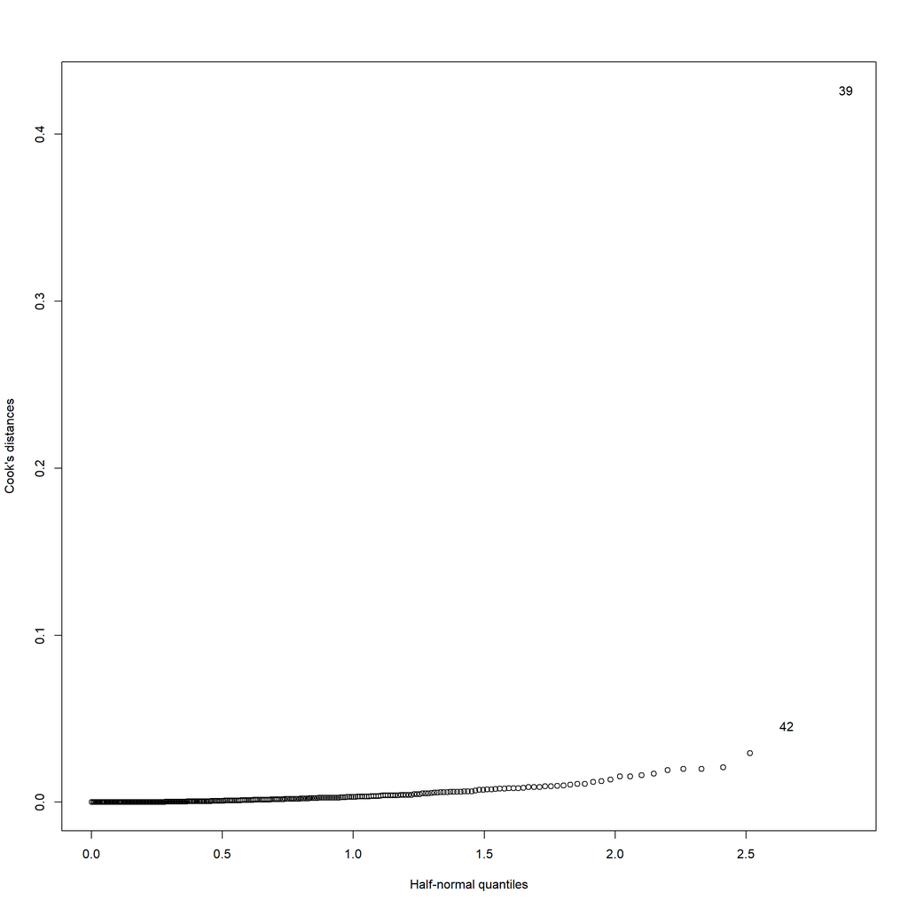

```r
# get the Cook's distances
cook <- cooks.distance(reducedfat)
faraway::halfnorm(cook, 2, ylab="Cook's distances")
```

```r
# now refit, leaving out two observations with Cook's distances > 0.04
reducedfat_ex <- lm(brozek ~ age+weight+height+abdom,data=fat,subset=(cooks.distance(reducedfat) < 0.04))
summary(reducedfat_ex)
```

```
##
## Call:
## lm(formula = brozek ~ age + weight + height + abdom, data = fat,
##     subset = (cooks.distance(reducedfat) < 0.04))
##
## Residuals:
##      Min       1Q   Median       3Q      Max
## -10.2277  -3.0198   0.0832   3.0011   9.3771
##
## Coefficients:
##              Estimate Std. Error t value Pr(>|t|)
## (Intercept) -27.96463   10.74054  -2.604  0.00979 **
## age          -0.00188    0.02403  -0.078  0.93772
## weight       -0.09334    0.03135  -2.978  0.00320 **
## height       -0.20813    0.14742  -1.412  0.15928
## abdom         0.84662    0.07547  11.218  < 2e-16 ***
## ---
## Signif. codes:  0 '***' 0.001 '**' 0.01 '*' 0.05 '.' 0.1 ' ' 1
##
## Residual standard error: 4.061 on 245 degrees of freedom
## Multiple R-squared:  0.7251, Adjusted R-squared:  0.7206
## F-statistic: 161.5 on 4 and 245 DF,  p-value: < 2.2e-16
```

The *p*-value and resulting significance level for the `weight` variable changed. The adjusted R-squared value increased from 0.7166 to 0.7206 and the F-statistic changed from 159.7 to 161.5.

8. Recompute the 95% prediction and 95% confidence intervals for the **mean** predictor values for the reduced model with the two most influential observations removed. Comment on whether removing the influential observations made much difference to the predicted values and their intervals. (1 mark)

```r
# get all the predictors as a matrix for new model
reducedfatexmod_matrix <- model.matrix(reducedfat_ex)

# calculate means for each of the predictor variables for new model
(mean_reducedfatex <- apply(reducedfatexmod_matrix, 2, mean))
```

```
## (Intercept)         age      weight      height       abdom
##      1.0000     44.8840    178.0832     70.3030     92.2868
```

```r
#use predict to calculate the prediction and confidence interval for mean body fat percentage for new model
predict(reducedfat_ex, new=as.data.frame(t(mean_reducedfatex)), interval="prediction")
```

```
##      fit      lwr      upr
## 1 18.828 10.81397 26.84203
```

```r
predict(reducedfat_ex, new=as.data.frame(t(mean_reducedfatex)), interval="confidence")
```

```
##      fit      lwr      upr
## 1 18.828 18.32216 19.33384
```

The predicted mean body fat percentage decreased from 18.938 to 18.828 with the two influential observations removed. The prediction interval narrowed slightly, by approximately 0.26. However, the confidence interval range remained the same, but had a 0.1 decrease on both the lower and upper values.

## Task 3 (10 marks)

In this task, you will be using the `hips` dataset which comes with the *faraway* package for R which you should already have installed. If not, install it now using the Packages tab in RStudio or the `install.packages()` function at R console prompt.

```r
# this loads the hips dataset and makes it available for code in
# subsequent code chunks.
data(hips, package="faraway")
```

The `hips` dataset comes from a study undertaken in the 1950s at the [Royal Mineral Hospital](https://en.wikipedia.org/wiki/Royal_National_Hospital_for_Rheumatic_Diseases) (now known as the Royal National Hospital for Rheumatic Diseases) in Bath, UK. The study involved patients with [ankylosing spondylitis](https://en.wikipedia.org/wiki/Ankylosing_spondylitis), an auto-immune disease which causes inflammation and eventual seizing up (ankylosis) of the joints of the spine, and to a lesser extent of the hips and shoulders. Patients were randomly allocated to either a treatment group, in which they received physiotherapy involving daily stretching exercises for their hip joints, or to a control group in which no stretching or other physiotherapy was provided. Hip mobility in terms of flexion (bringing the knee up towards the chest) and rotation (rotating the knee inwards and outwards) were measured on each side (right and left), before the study commenced, and after it was completed.

1. (2.5 marks)

Carry out a brief exploratory data analysis, examining each variable, and the relationships between all the variables. How many patients were assigned to each group (treatment or control). Are there differences in the variables between the two groups (treatment and control) or sides (left or right)? Show your code and written explanations.

```r
#preview dataset
head(hips)
```

```
##   fbef faft rbef raft   grp  side person
## 1  125  126   25   36 treat right      1
## 2  120  127   35   37 treat  left      1
## 3  135  135   28   40 treat right      2
## 4  135  135   24   34 treat  left      2
## 5  100  113   26   30 treat right      3
## 6  110  115   24   26 treat  left      3
```

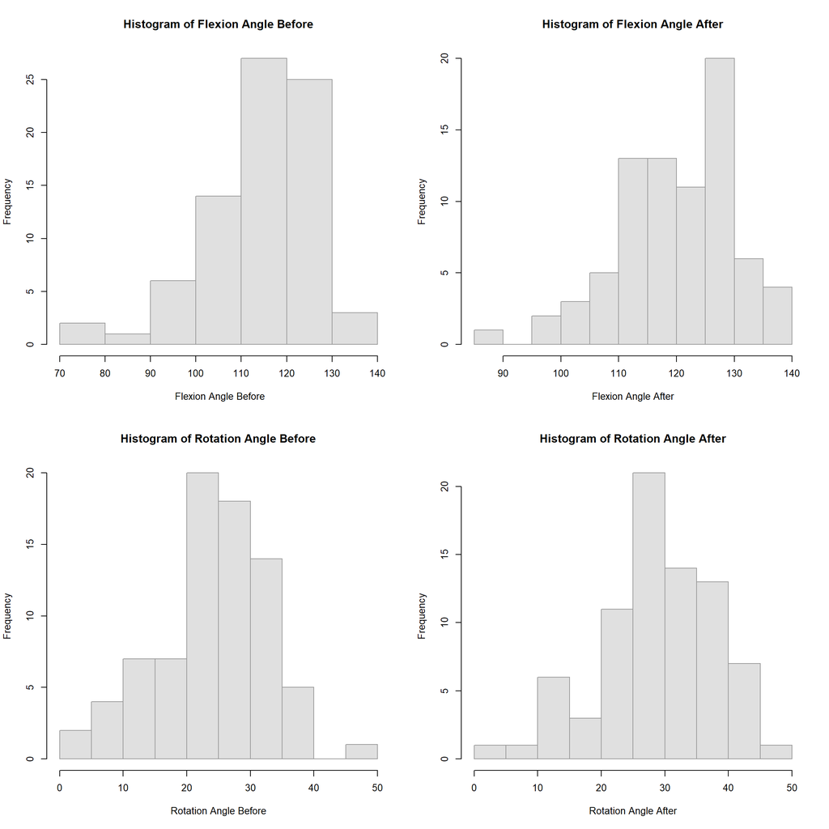

```r
#histograms for continuous variables
par(mfrow=c(2,2))
hist(hips$fbef,
     main="Histogram of Flexion Angle Before",
     xlab=" Flexion Angle Before", col="gray88", border="gray60")

hist(hips$faft,
     main="Histogram of Flexion Angle After",
     xlab="Flexion Angle After", col="gray88", border="gray60")

hist(hips$rbef,
     main="Histogram of Rotation Angle Before",
     xlab="Rotation Angle Before", col="gray88", border="gray60")

hist(hips$raft,
     main="Histogram of Rotation Angle After",
     xlab="Rotation Angle After", col="gray88", border="gray60")
```

```r
#QQ-Plots for continuous variables
qqnorm(hips$fbef)
qqline(hips$fbef)
shapiro.test(hips$fbef)
```

```
##
##  Shapiro-Wilk normality test
##
## data:  hips$fbef
## W = 0.93592, p-value = 0.0006982
```

```r
qqnorm(hips$faft)
qqline(hips$faft)
shapiro.test(hips$faft)
```

```
##
##  Shapiro-Wilk normality test
##
## data:  hips$faft
## W = 0.96937, p-value = 0.05701
```

```r
qqnorm(hips$rbef)
qqline(hips$rbef)
shapiro.test(hips$rbef)
```

```
##
##  Shapiro-Wilk normality test
##
## data:  hips$rbef
## W = 0.97801, p-value = 0.1963
```

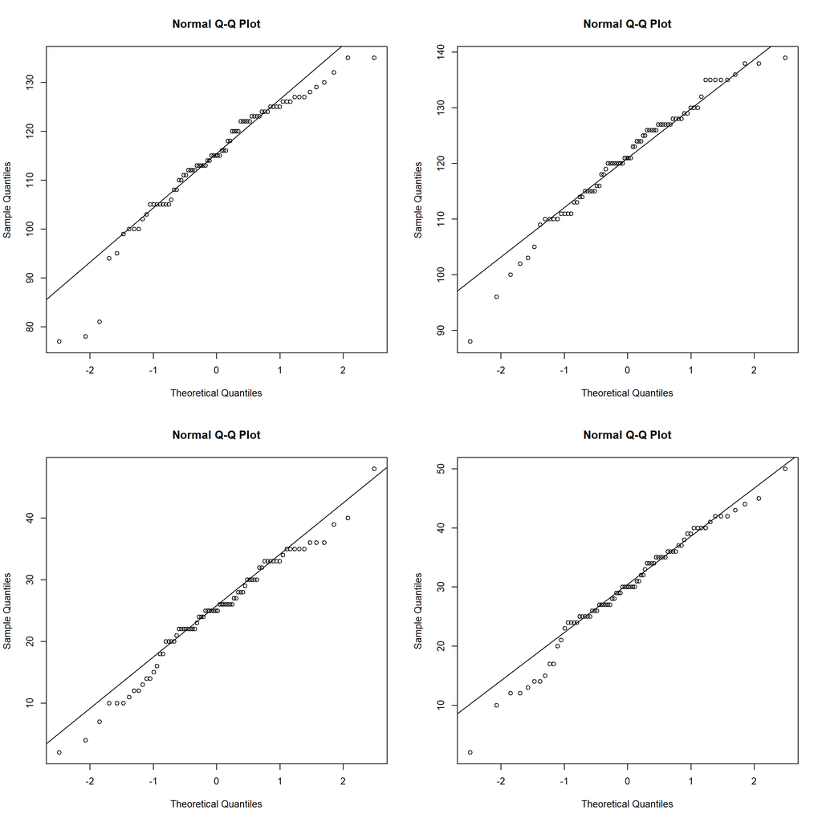

```r
qqnorm(hips$raft)
qqline(hips$raft)
```

```r
shapiro.test(hips$raft)
```

```
##
##  Shapiro-Wilk normality test
##
## data:  hips$raft
## W = 0.97529, p-value = 0.1333
```

```r
# summary statistics for each variable
summary(hips$fbef)
```

```
##    Min. 1st Qu.  Median    Mean 3rd Qu.    Max.
##    77.0   108.0   115.0   114.5   123.0   135.0
```

```r
summary(hips$faft)
```

```
##    Min. 1st Qu.  Median    Mean 3rd Qu.    Max.
##    88.0   115.0   121.0   120.8   127.0   139.0
```

```r
summary(hips$rbef)
```

```
##    Min. 1st Qu.  Median    Mean 3rd Qu.    Max.
##    2.00   20.25   25.00   24.85   31.50   48.00
```

```r
summary(hips$raft)
```

```
##    Min. 1st Qu.  Median    Mean 3rd Qu.    Max.
##    2.00   25.00   30.00   29.71   36.00   50.00
```

```r
summary(hips$grp)
```

```
## control   treat
##      24      54
```

```r
summary(hips$side)
```

```
## right  left
##    39    39
```

```r
summary(hips$person)
```

```
##  1  2  3  4  5  6  7  8  9 10 11 12 13 14 15 16 17 18 19 20 21 22 23 24 25 26
##  2  2  2  2  2  2  2  2  2  2  2  2  2  2  2  2  2  2  2  2  2  2  2  2  2  2
## 27 28 29 30 31 32 33 34 35 36 37 38 39
##  2  2  2  2  2  2  2  2  2  2  2  2  2
```

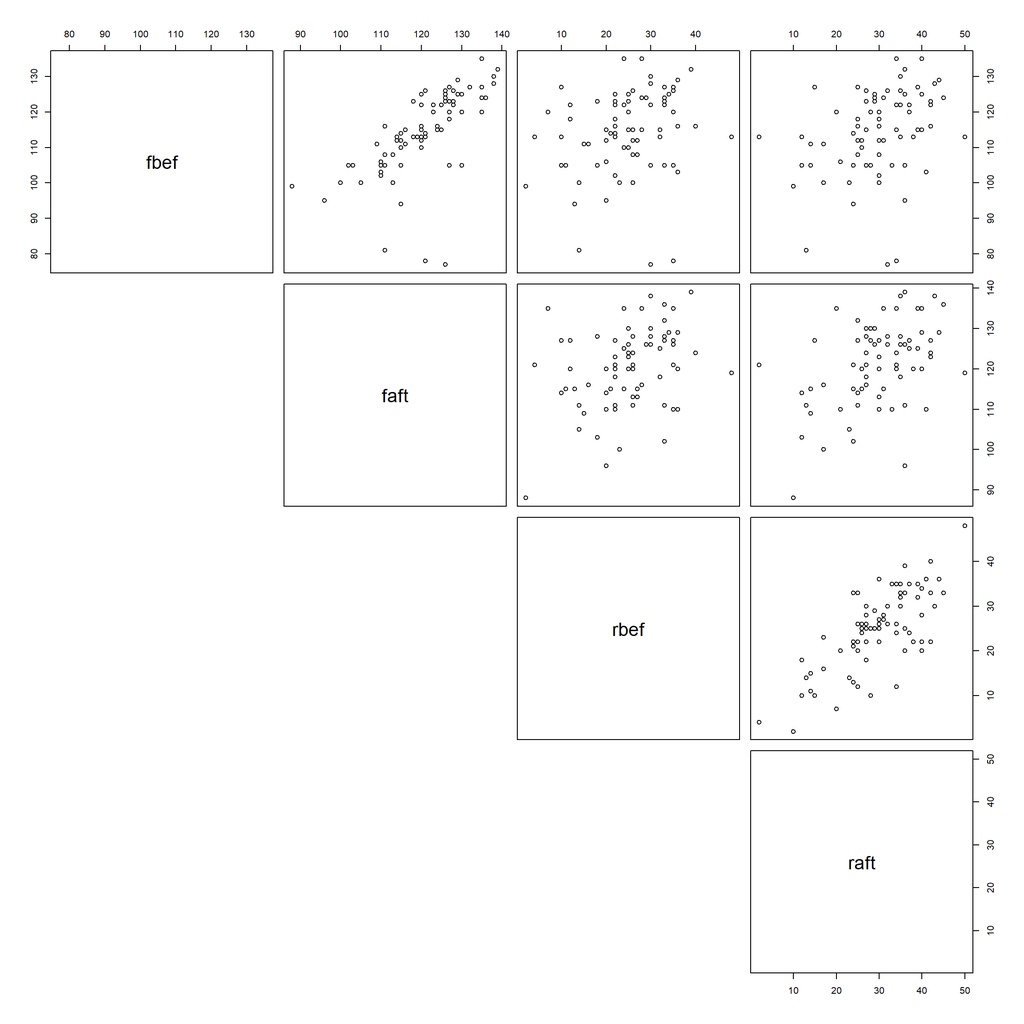

```r
#A scatterplot matrix of bivariate relationships of predictor variables

pairs(hips[,1:4], pch = 1, lower.panel = NULL)
```

```r
#correlation between predictor variables
#create and display correlation matrix using Hmisc package
corr <- rcorr(as.matrix(hips[,1:4]))
corr
```

```
##      fbef faft rbef raft
## fbef 1.00 0.66 0.20 0.35
## faft 0.66 1.00 0.32 0.45
## rbef 0.20 0.32 1.00 0.74
## raft 0.35 0.45 0.74 1.00
##
## n= 78
##
##
## P
##      fbef   faft   rbef   raft
## fbef        0.0000 0.0744 0.0019
## faft 0.0000        0.0037 0.0000
## rbef 0.0744 0.0037        0.0000
## raft 0.0019 0.0000 0.0000
```

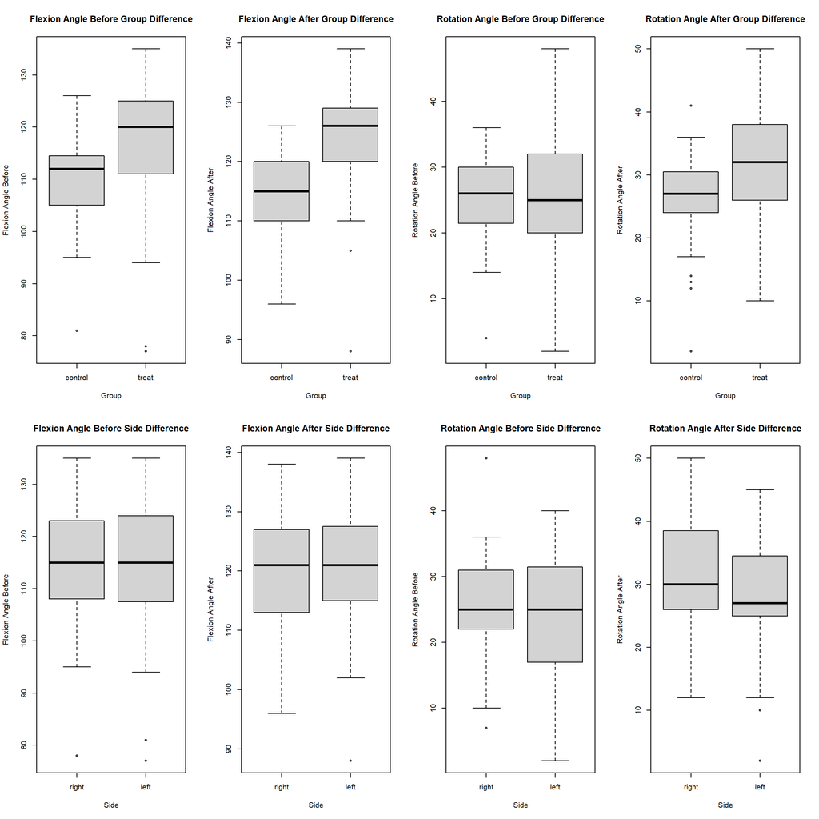

```r
#boxplots to examine variables by groups and sides
par(mfrow=c(2,4))
boxplot(fbef~grp,data=hips, main="Flexion Angle Before Group Difference",
   xlab="Group", ylab="Flexion Angle Before")

boxplot(faft~grp,data=hips, main="Flexion Angle After Group Difference",
   xlab="Group", ylab="Flexion Angle After")

boxplot(rbef~grp,data=hips, main="Rotation Angle Before Group Difference",
   xlab="Group", ylab="Rotation Angle Before")

boxplot(raft~grp,data=hips, main="Rotation Angle After Group Difference",
   xlab="Group", ylab="Rotation Angle After")

boxplot(fbef~side,data=hips, main="Flexion Angle Before Side Difference",
   xlab="Side", ylab="Flexion Angle Before")

boxplot(faft~side,data=hips, main="Flexion Angle After Side Difference",
   xlab="Side", ylab="Flexion Angle After")

boxplot(rbef~side,data=hips, main="Rotation Angle Before Side Difference",
   xlab="Side", ylab="Rotation Angle Before")

boxplot(raft~side,data=hips, main="Rotation Angle After Side Difference",
   xlab="Side", ylab="Rotation Angle After")
```

From the above outputs, I see that there are 39 total patients in the dataset. Out of these 39 patients, 12 were assigned to the control group and 27 were assigned to the treatment group.

I observe that the `fbef` variable is between 70 and 140, and the highest frequency is concentrated between 110 and 130. The `faft` variable is between 90 and 140, and the highest frequency is concentrated between 110 and 130 with a spike at 125 to 140. The `rebf` variable is between 0 and 50, and the highest frequency is concentrated between 20 and 35. Lastly, the `raft` variable is between 0 and 50, and the highest frequency is concentrated between 25 and 30. From the histograms, QQ-plots, and Shapiro-Wilk normality test, I observe that `faft`, `rbef`, and `raft` predictor variables appear to be approximately normally distributed, while `fbef` does not appear to be normally distributed.

From the boxplot output, I observe that there there is minimal differences for the four predictor variables between the left and right side. The `raft`variable has a slightly higher median for the right side versus the left. The `rbef` variable has a large IQR range for the left side versus the right. However, the `fbef`, `faft`, and `raft` variables all have a higher median for the treatment group versus the control group. The `rbef` median for the control group is slightly higher than the treatment group, but the treatment group has a larger IQR range.

Also, I observe relationships between a few of the predictors in the dataset. I observe a positive relationship in the scatterplots between `fbef` and `faft` and `rbef` and `raft`. This is confirmed when I observe the correlations between these variables, a value of 0.66 and 0.74. This makes sense as the flexion and rotation angles before would correlate with the after values for the majority of patients.

2. (1 mark)

Create two new variables, called `flexdiff` and `rotdiff`, which contain the difference between the before and after flexion, or the before and after rotation, respectively. Use histograms to show the distribution of these new variables for each of the two groups (treatment or control). What do you observe?

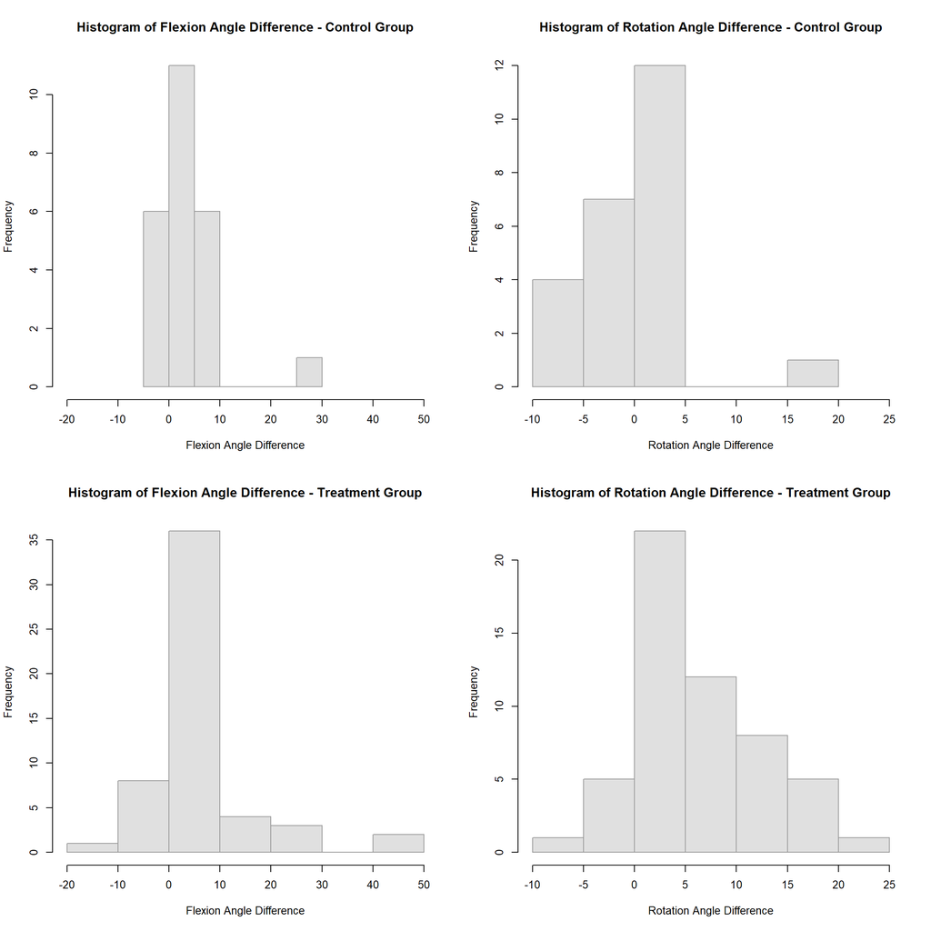

```r
hips$flexdiff = hips$faft - hips$fbef
hips$rotdiff = hips$raft - hips$rbef

par(mfrow=c(2,2))

hist(subset(hips$flexdiff,hips$grp=='control'),
     main="Histogram of Flexion Angle Difference - Control Group",
     xlab="Flexion Angle Difference", col="gray88", border="gray60",
     xlim=c(-20, 50))

hist(subset(hips$rotdiff,hips$grp=='control'),
     main="Histogram of Rotation Angle Difference - Control Group",
     xlab="Rotation Angle Difference", col="gray88", border="gray60",
     xlim=c(-10, 25))

hist(subset(hips$flexdiff,hips$grp=='treat'),
     main="Histogram of Flexion Angle Difference - Treatment Group",
     xlab="Flexion Angle Difference", col="gray88", border="gray60",
     xlim=c(-20, 50))

hist(subset(hips$rotdiff,hips$grp=='treat'),
     main="Histogram of Rotation Angle Difference - Treatment Group",
     xlab="Rotation Angle Difference", col="gray88", border="gray60",
      xlim=c(-10, 25))
```

I observe that the treatment groups for both the Flexion and Rotation angle differences have a higher frequency of larger changes than the control groups. The Rotation angle shows a marked improvement for the treatment group especially. Both the control and treatment groups have the highest frequency between 0 and 5, but the treatment group has a higher frequency for differences above 5, and a lower frequency for negative differences. The Flexion angle has the higher frequency between 0 and 10 for both the treatment and control groups. However, the treatment group has a higher frequency of differences above 10, and also has more extreme differences for both positive and negative differences. This shows a possible treatment effect, but more exploration is needed to confirm what the graphs are showing.

3. (1.5 marks)

The data set contains two observations for each patient — one for the right hip, and one for the left hip. If we fit standard linear regression models using OLS, should we analyse all the data in one model, or should we fit two separate models, one for the right side hips and the other for the left side hips, or should we fit one model and include the `side` variable as a predictor? Justify your answer based on the assumptions we rely on for OLS linear models.

Two separate models, one for the right side hips and the other for the left side hips, will need to be fit and used. The reasons being that there will multicollinearity issues since the observations for the right and left side will be highly correlated. The observations will not be independent since each person has two hips and thus two observations in the dataset. This will also lead to autocorrelation in the error terms as the error for one hip will have systematic correlation for the other hip. Both of these assumptions are violated by analysing the data in one model, and separate models should be used for each side to ensure the OLS procedure produces the best estimates.

4. (1 mark)

Fit a model to the data for right-side hips only. Use `flexdiff` as the outcome, and the `grp` variable as a sole predictor. Report on whether there appears to be a treatment effect. Repeat this for the left hips.

```r
#fit linear model for right side hips only
flexrh_lm <- lm(flexdiff~grp,data=subset(hips,hips$side=='right'))
summary(flexrh_lm)
```

```
##
## Call:
## lm(formula = flexdiff ~ grp, data = subset(hips, hips$side ==
##     "right"))
##
## Residuals:
##     Min      1Q  Median      3Q     Max
## -11.852  -2.852  -0.667   1.741  36.148
##
## Coefficients:
##             Estimate Std. Error t value Pr(>|t|)
## (Intercept)    3.667      2.094   1.751   0.0882 .
## grptreat       3.185      2.516   1.266   0.2135
## ---
## Signif. codes:  0 '***' 0.001 '**' 0.01 '*' 0.05 '.' 0.1 ' ' 1
##
## Residual standard error: 7.252 on 37 degrees of freedom
## Multiple R-squared:  0.04151,    Adjusted R-squared:  0.01561
## F-statistic: 1.602 on 1 and 37 DF,  p-value: 0.2135
```

```r
#fit linear model for left side hips only
flexlh_lm <- lm(flexdiff~grp,data=subset(hips,hips$side=='left'))
summary(flexlh_lm)
```

```
##
## Call:
## lm(formula = flexdiff ~ grp, data = subset(hips, hips$side ==
##     "left"))
##
## Residuals:
##     Min      1Q  Median      3Q     Max
## -19.111  -6.014  -2.111   2.486  40.889
##
## Coefficients:
##             Estimate Std. Error t value Pr(>|t|)
## (Intercept)    3.917      3.113   1.258    0.216
## grptreat       4.194      3.742   1.121    0.270
##
## Residual standard error: 10.78 on 37 degrees of freedom
## Multiple R-squared:  0.03285,    Adjusted R-squared:  0.006708
## F-statistic: 1.257 on 1 and 37 DF,  p-value: 0.2695
```

No, there does not appear to be a treatment effect for the flexion angle difference. For both the right and left side, the `grp` variable is not significant at any level.

5. (1 mark)

Repeat all aspects of Q4 but substituting the `rotdiff` variable as the outcome.

```r
#fit linear model for right side hips only
rotrh_lm <- lm(rotdiff~grp,data=subset(hips,hips$side=='right'))
summary(rotrh_lm)
```

```
##
## Call:
## lm(formula = rotdiff ~ grp, data = subset(hips, hips$side ==
##     "right"))
##
## Residuals:
##     Min      1Q  Median      3Q     Max
## -8.5556 -3.8611  0.4444  2.3333 13.8333
##
## Coefficients:
##             Estimate Std. Error t value Pr(>|t|)
## (Intercept)    2.167      1.626   1.332    0.191
## grptreat       5.389      1.955   2.757    0.009 **
## ---
## Signif. codes:  0 '***' 0.001 '**' 0.01 '*' 0.05 '.' 0.1 ' ' 1
##
## Residual standard error: 5.634 on 37 degrees of freedom
## Multiple R-squared:  0.1704, Adjusted R-squared:  0.148
## F-statistic: 7.601 on 1 and 37 DF,  p-value: 0.009004
```

```r
#fit linear model for left side hips only
rotlh_lm <- lm(rotdiff~grp,data=subset(hips,hips$side=='left'))
summary(rotlh_lm)
```

```
##
## Call:
## lm(formula = rotdiff ~ grp, data = subset(hips, hips$side ==
##     "left"))
##
## Residuals:
##    Min     1Q Median     3Q    Max
## -13.63  -3.63  -0.75   4.25  16.37
##
## Coefficients:
##             Estimate Std. Error t value Pr(>|t|)
## (Intercept)   -0.250      1.821  -0.137   0.8916
## grptreat       5.880      2.189   2.686   0.0108 *
## ---
## Signif. codes:  0 '***' 0.001 '**' 0.01 '*' 0.05 '.' 0.1 ' ' 1
##
## Residual standard error: 6.309 on 37 degrees of freedom
## Multiple R-squared:  0.1632, Adjusted R-squared:  0.1406
## F-statistic: 7.216 on 1 and 37 DF,  p-value: 0.01076
```

Yes, there does appear to be a treatment effect for the rotation angle difference. The `grp` variable is significant at the 99% significance level for the right side hips, and 95% significance level for the left side hips.

6. (1 mark)

For the right-side hips only, re-fit the models you created for Q4 and Q5, but add the “before” values for flexion and rotation to each model as additional predictors. Report briefly on what you find.

```r
#fit linear model for flexion for right side hips only
flexrh_lm_ext <- lm(flexdiff~grp+fbef,data=subset(hips,hips$side=='right'))
summary(flexrh_lm_ext)
```

```
##
## Call:
## lm(formula = flexdiff ~ grp + fbef, data = subset(hips, hips$side ==
##     "right"))
##
## Residuals:
##      Min       1Q   Median       3Q      Max
## -12.2362  -2.6988  -0.3856   2.6019  21.1591
##
## Coefficients:
##             Estimate Std. Error t value Pr(>|t|)
## (Intercept) 45.91158    9.97406   4.603 5.02e-05 ***
## grptreat     5.90756    2.16784   2.725 0.009861 **
## fbef        -0.38434    0.08937  -4.300 0.000124 ***
## ---
## Signif. codes:  0 '***' 0.001 '**' 0.01 '*' 0.05 '.' 0.1 ' ' 1
##
## Residual standard error: 5.976 on 36 degrees of freedom
## Multiple R-squared:  0.3668, Adjusted R-squared:  0.3316
## F-statistic: 10.43 on 2 and 36 DF,  p-value: 0.0002679
```

```r
#fit linear model for rotation for right side hips only
rotrh_lm_ext <- lm(rotdiff~grp+rbef,data=subset(hips,hips$side=='right'))
summary(rotrh_lm_ext)
```

```
##
## Call:
## lm(formula = rotdiff ~ grp + rbef, data = subset(hips, hips$side ==
##     "right"))
##
## Residuals:
##     Min      1Q  Median      3Q     Max
## -9.0195 -3.4012 -0.1606  2.4845 12.3900
##
## Coefficients:
##             Estimate Std. Error t value Pr(>|t|)
## (Intercept)   7.5463     3.3889   2.227   0.0323 *
## grptreat      4.9442     1.9146   2.582   0.0140 *
## rbef         -0.1968     0.1097  -1.794   0.0812 .
## ---
## Signif. codes:  0 '***' 0.001 '**' 0.01 '*' 0.05 '.' 0.1 ' ' 1
##
## Residual standard error: 5.472 on 36 degrees of freedom
## Multiple R-squared:  0.2385, Adjusted R-squared:  0.1962
## F-statistic: 5.638 on 2 and 36 DF,  p-value: 0.00741
```

With the `fbef` variable added for the flexion angle difference model, the `grp` variable becomes significant at the 99% significance level and the `fbef` variable is significant at the 99.9% significance level. However, with the `rbef` variable added for the rotation angle difference model, the `grp` variable becomes less significant (still significant at the 95% significance level) and the `rbef` is only significant at the 90% significance level. Both models did see an increase in their respective Adjusted-R square values, but the increase was more drastic for the flexion angle difference model.

7. (1 mark)

Use both “before” and “after” values as predictors (as well as `grp`) in a model using right-side hips only, with `rotdiff` as the outcome. Comment on what is wrong with this model.

```r
#fit linear model for rotation for right side hips only
rotrh_lm_ext_two <- lm(rotdiff~grp+rbef+raft,data=subset(hips,hips$side=='right'))
summary(rotrh_lm_ext_two)
```

```
##
## Call:
## lm(formula = rotdiff ~ grp + rbef + raft, data = subset(hips,
##     hips$side == "right"))
##
## Residuals:
##        Min         1Q     Median         3Q        Max
## -8.108e-15 -1.328e-15 -6.829e-16  2.763e-16  2.599e-14
##
## Coefficients:
##               Estimate Std. Error    t value Pr(>|t|)
## (Intercept)  7.609e-15  3.234e-15  2.352e+00   0.0244 *
## grptreat     2.157e-15  1.865e-15  1.157e+00   0.2553
## rbef        -1.000e+00  1.549e-16 -6.458e+15   <2e-16 ***
## raft         1.000e+00  1.491e-16  6.706e+15   <2e-16 ***
## ---
## Signif. codes:  0 '***' 0.001 '**' 0.01 '*' 0.05 '.' 0.1 ' ' 1
##
## Residual standard error: 4.896e-15 on 35 degrees of freedom
## Multiple R-squared:      1,  Adjusted R-squared:      1
## F-statistic: 1.968e+31 on 3 and 35 DF,  p-value: < 2.2e-16
```

The model is “too perfect”. Since the outcome variable, `rotdiff`, is a calculation based on `rbef` and `raft`, there is perfect predictive power in the model. Because the outcome variable is a linear combination of the two predictive variables, the matrix is not full rank and thus not invertible. This model is useless in reality and not valid. h. (1 mark)

Plot fitted values for the hip rotation model you fitted in Q6, holding the `rbef` variable fixed at the mean value of that variable for right hips across both treatment and control groups.

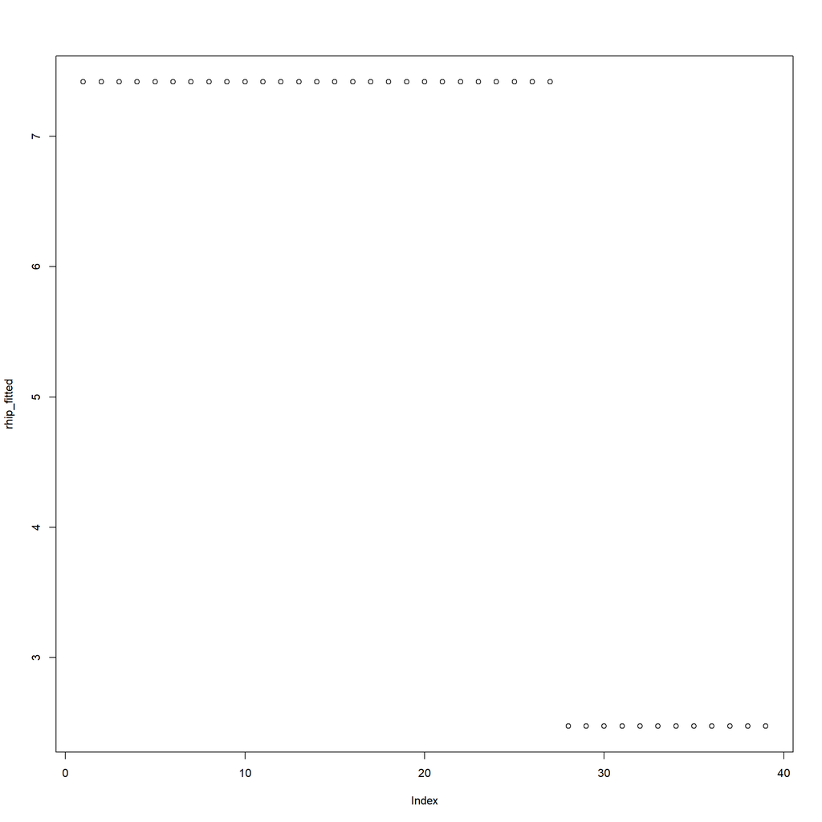

```r
# new data frame with only grp and mean rbef value
rhip_mean_rbef <- mean(subset(hips$rbef,hips$side=='right'))
rhip_df <- subset(hips,hips$side=='right',select='grp')
rhip_df$rbef <- rhip_mean_rbef

#create object with fitted values and plot
rhip_fitted <- predict(rotrh_lm_ext,new=rhip_df)
plot(rhip_fitted)
```

### Save and knit

**Reminder**: don’t forget to save this file and to knit it to check that everything works.

## Submit your assignment

When you have finished, and are satisfied with your assignment solutions, and this file knits without errors and the output looks the way you want, then you should upload both the .Rmd file and rendered (knited) .html file to the assessment respective upload box in OL.